# Lab 7: RNA-Seq workflow: gene-level exploratory analysis and differential expression

## 8. Removing Hidden Batch Effects

```r
# if you did not know there were different cell lines involved, then the cell line effect on the counts would represent hidden and unwanted variation that might be affecting many or all of genes in dataset; use methods, like sva (surrigta variables" estimated variables that are accounted for in anaylsis) package, to detect such groupings of samples; can use RUVSeq: uses factors of unwanted variation with acronym "remove unwanted variation"
```

## 8.1 Using SVA with DESeq2

```r
library("sva")
```

# obtain a matrix of nromalized counts for which average count across samples is larger than 1; trying to recover hidden batch effects

```r
# using reduced, or null, model matrix and using full model matrix with dex with only intercept term; we can estimate 2 surrogate variables from this
dat  <- counts(dds, normalized = TRUE)
idx  <- rowMeans(dat) > 1
dat  <- dat[idx, ]
mod  <- model.matrix(~ dex, colData(dds))
mod0 <- model.matrix(~   1, colData(dds))
svseq <- svaseq(dat, mod, mod0, n.sv = 2)
```

```
## Number of significant surrogate variables is:  2
## Iteration (out of 5 ):1  2  3  4  5
```

```r
svseq$sv
```

```
##            [,1]        [,2]
## [1,]  0.2465669 -0.51599084
## [2,]  0.2588137 -0.59462876
## [3,]  0.1384516  0.24920662
## [4,]  0.2179075  0.37716083
## [5,] -0.6042910 -0.06305844
## [6,] -0.6138795 -0.03623320
## [7,]  0.1821306  0.30328185
## [8,]  0.1743002  0.28026195
```

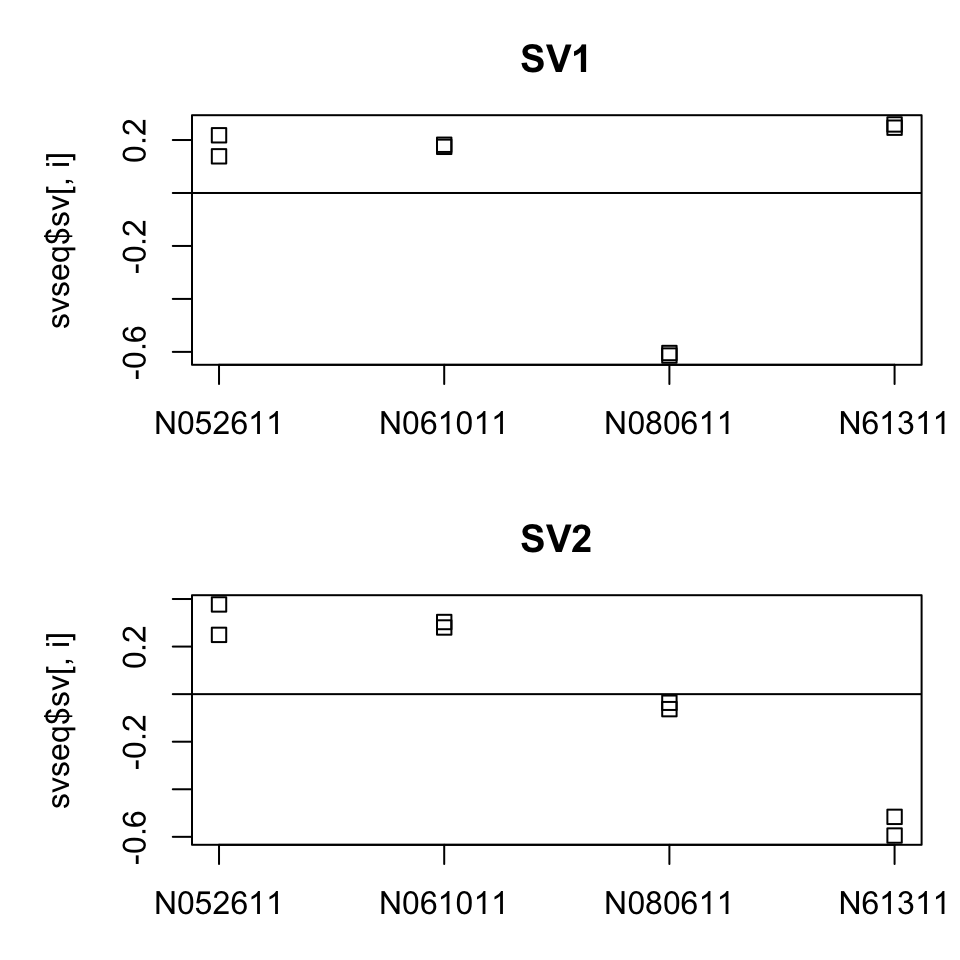

```r
# need to know cell lines to see how well SVA method did at recovering variables

par(mfrow = c(2, 1), mar = c(3,5,3,1))
for (i in 1:2) {
  stripchart(svseq$sv[, i] ~ dds$cell, vertical = TRUE, main = paste0("SV", i))
  abline(h = 0)
}
```

```r
# Surrogate variables 1 and 2 plotted over cell line. Here, we know the hidden source of variation (cell line), and therefore can see how the SVA procedure is able to identify a source of variation which is correlated with cell line.
```

# to use SV to remove any effect on counts from surrogate variables, add two surrogate variables as columns and then to design

```r
ddssva <- dds
ddssva$SV1 <- svseq$sv[,1]
ddssva$SV2 <- svseq$sv[,2]
design(ddssva) <- ~ SV1 + SV2 + dex

# produces results controlling surrogate values by running DESeq with new design
```

## 8.2 Using RUV with DESeq2

# use RUV method to detect hidden batch effects

```r
library("RUVSeq")
```

```r
# use RUVg function to estimate factors of unwanted variation; a difference compared to SVA is that we first run DESeq and results to obtain p-values for the analysis without knowing about the batches - supposing that we have results table res, we then pull out empirical control genes by looking at genes that do not have small p-valie

set <- newSeqExpressionSet(counts(dds))
idx  <- rowSums(counts(set) > 5) >= 2
set  <- set[idx, ]
set <- betweenLaneNormalization(set, which="upper")
not.sig <- rownames(res)[which(res$pvalue > .1)]
empirical <- rownames(set)[ rownames(set) %in% not.sig ]
set <- RUVg(set, empirical, k=2)
pData(set)
```

```
##                     W_1         W_2
## SRR1039508 -0.224881168  0.42992983
## SRR1039509 -0.249022928  0.53858506
## SRR1039512  0.001460949  0.01437385
## SRR1039513 -0.175547525  0.08408354
## SRR1039516  0.599387535 -0.02512358
## SRR1039517  0.590516825 -0.02549392
## SRR1039520 -0.241071948 -0.50369551
## SRR1039521 -0.300841739 -0.51265927
```

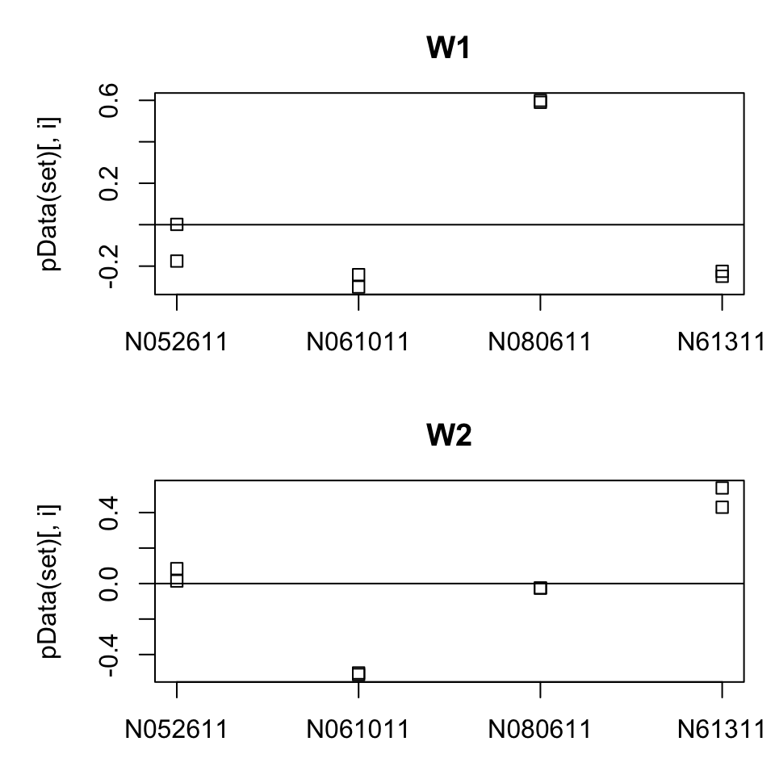

```r
# plot factors estimated

par(mfrow = c(2, 1), mar = c(3,5,3,1))
for (i in 1:2) {
  stripchart(pData(set)[, i] ~ dds$cell, vertical = TRUE, main = paste0("W", i))
  abline(h = 0)
}
```

```r
# Factors of unwanted variation plotted over cell line.

# add control factors to DESeqDataSet and to design
ddsruv <- dds
ddsruv$W1 <- set$W_1
ddsruv$W2 <- set$W_2
design(ddsruv) <- ~ W1 + W2 + dex
```

## 9. Time Course Experiments

```r
# DESeq2 can be used to analyze time course eperiments (e.g., find genes that react in a condition-specific manner over time, compared to baseline samples)

# fision data package, which contains gene counts for an RNA-seq time course of fission yeast, demonstrates basic time course analysis; yeast were exposed to oxidative stress and half of sample contained a deletion of gene atf21; a design formula that models the strain difference at time 0, the difference over time, and any strain-specific differences over time
```

```r
library("fission")
data("fission")
ddsTC <- DESeqDataSet(fission, ~ strain + minute + strain:minute)

# performing a likelihood ratio test, where we remove strain-specific differences over time; genes w/small p values from this test are those which at one or more time points after time 0 shows a strain-specific effect
ddsTC <- DESeq(ddsTC, test="LRT", reduced = ~ strain + minute)
resTC <- results(ddsTC)
resTC$symbol <- mcols(ddsTC)$symbol
head(resTC[order(resTC$padj),], 4)
```

```
## log2 fold change (MLE): strainmut.minute180
## LRT p-value: '~ strain + minute + strain:minute' vs '~ strain + minute'
## DataFrame with 4 rows and 7 columns
##               baseMean log2FoldChange     lfcSE      stat      pvalue
##              <numeric>      <numeric> <numeric> <numeric>   <numeric>
## SPBC2F12.09c   174.671     -2.6567195  0.752261   97.2834 1.97415e-19
## SPAC1002.18    444.505     -0.0509321  0.204299   56.9536 5.16955e-11
## SPAC1002.19    336.373     -0.3927490  0.573494   43.5339 2.87980e-08
## SPAC1002.17c   261.773     -1.1387648  0.606129   39.3158 2.05137e-07
##                     padj      symbol
##                <numeric> <character>
## SPBC2F12.09c 1.33453e-15       atf21
## SPAC1002.18  1.74731e-07        urg3
## SPAC1002.19  6.48916e-05        urg1
## SPAC1002.17c 3.46682e-04        urg2
```

# this is just one tes that is applied to time series data; can use models of the counts as a smooth function of time and include an interaction term of the condition with smooth function

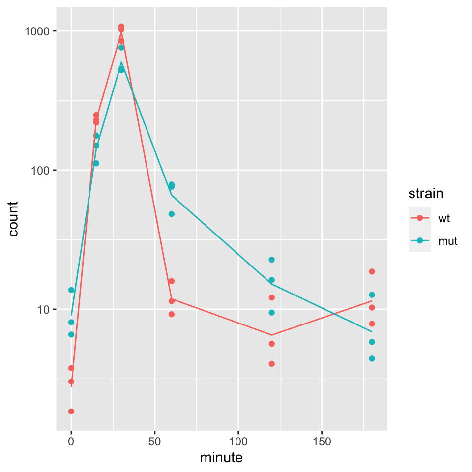

```r
# can use ggplot2 to plot counts for groups over time for the gene with smallest adjusted p value, testing for condition-dependent time profile and accounting for differences at time 0
fiss <- plotCounts(ddsTC, which.min(resTC$padj),
                   intgroup = c("minute","strain"), returnData = TRUE)
fiss$minute <- as.numeric(as.character(fiss$minute))
ggplot(fiss,
  aes(x = minute, y = count, color = strain, group = strain)) +
  geom_point() + stat_summary(fun.y=mean, geom="line") +
  scale_y_log10()
```

```r
# Normalized counts for a gene with condition-specific changes over time.
```

```r
# Wald tests for log2 fold changes at individual time points can be investigated using test argument to result

resultsNames(ddsTC)
```

```
##  [1] "Intercept"           "strain_mut_vs_wt"    "minute_15_vs_0"
##  [4] "minute_30_vs_0"      "minute_60_vs_0"      "minute_120_vs_0"
##  [7] "minute_180_vs_0"     "strainmut.minute15"  "strainmut.minute30"
## [10] "strainmut.minute60"  "strainmut.minute120" "strainmut.minute180"
```

```r
res30 <- results(ddsTC, name="strainmut.minute30", test="Wald")
res30[which.min(resTC$padj),]
```

```
## log2 fold change (MLE): strainmut.minute30
## Wald test p-value: strainmut.minute30
## DataFrame with 1 row and 6 columns
##               baseMean log2FoldChange     lfcSE      stat      pvalue      padj
##              <numeric>      <numeric> <numeric> <numeric>   <numeric> <numeric>
## SPBC2F12.09c   174.671       -2.60047  0.634343  -4.09947 4.14099e-05  0.279931
```

```r
# can cluster significant genes by profiles; extract matrix of shrunken log2 fold changes using coef function

betas <- coef(ddsTC)
colnames(betas)
```

```
##  [1] "Intercept"           "strain_mut_vs_wt"    "minute_15_vs_0"
##  [4] "minute_30_vs_0"      "minute_60_vs_0"      "minute_120_vs_0"
##  [7] "minute_180_vs_0"     "strainmut.minute15"  "strainmut.minute30"
## [10] "strainmut.minute60"  "strainmut.minute120" "strainmut.minute180"
```

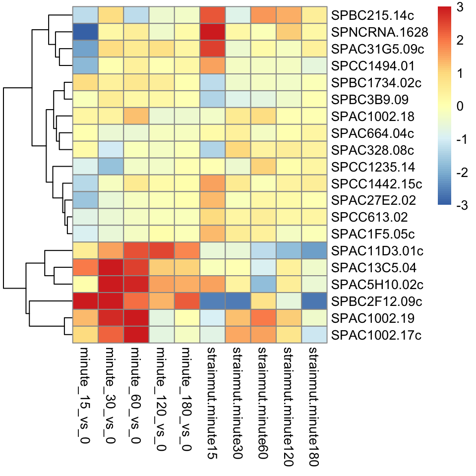

```r
# plot log2 fold changes in heatmap
topGenes <- head(order(resTC$padj),20)
mat <- betas[topGenes, -c(1,2)]
thr <- 3
mat[mat < -thr] <- -thr
mat[mat > thr] <- thr
pheatmap(mat, breaks=seq(from=-thr, to=thr, length=101),
         cluster_col=FALSE)
```

```r
# Heatmap of log2 fold changes for genes with smallest adjusted p value. The bottom set of genes show strong induction of expression for the baseline samples in minutes 15-60 (red boxes in the bottom left corner), but then have slight differences for the mutant strain (shown in the boxes in the bottom right corner)
```

# REFERENCE

```r
citation("rnaseqGene")
```

```
##
##   Love, M.I., Anders, S., Kim, V., Huber, W. RNA-Seq workflow:
##   gene-level exploratory analysis and differential expression
##   F1000Research (2015)
##
## A BibTeX entry for LaTeX users is
##
##   @Article{,
##     title = {RNA-Seq workflow: gene-level exploratory analysis and differential expression},
##     author = {Michael I. Love and Simon Anders and Vladislav Kim and Wolfgang Huber},
##     year = {2015},
##     journal = {F1000Research},
##     doi = {10.12688/f1000research.7035},
##   }
```